# Data Science Capstone - Milestone Report

Luis Ruiz

2026-04-30

## Overview

This report presents an exploratory analysis of the Coursera SwiftKey dataset used for building a text prediction model. The dataset consists of three files in English: blogs, news, and Twitter. The goal is to understand the basic structure and content of the data before building the prediction algorithm and Shiny app.

## 1. Basic File Statistics

Table 1: Summary statistics of the three source files

| File | Size (MB) | Lines | Total Words | Avg Words/Line |
| --- | --- | --- | --- | --- |
| Blogs | 210.2 | 899,288 | 37,581,907 | 41.8 |
| News | 205.8 | 1,010,242 | 34,858,293 | 34.5 |
| Twitter | 167.1 | 2,360,148 | 30,162,832 | 12.8 |

The three files together contain over 4 million lines and roughly 100 million words. Twitter entries are the shortest on average (~13 words per line), while blogs are the longest (~42 words per entry).

## 2. Sampling

Given the file sizes, a random sample of 1% per file is used for the exploratory analysis to keep computation manageable.

## 3. Word Length Distribution

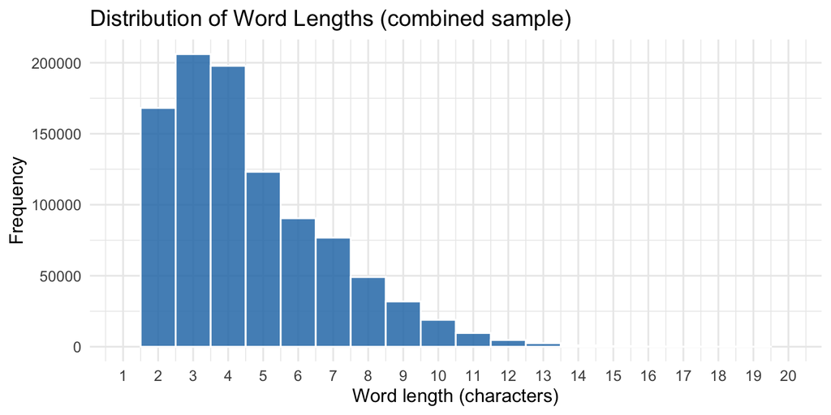

Most words are between 3 and 8 characters long, with a peak around 3-4 characters, consistent with the high frequency of short function words in English.

## 4. Line Length Distribution by Source

[figure not shown]

Twitter entries cluster tightly below 30 words due to the character limit. News and blog entries show broader distributions, with some blog posts exceeding 200 words per paragraph.

## 5. Top Words (after removing stopwords)

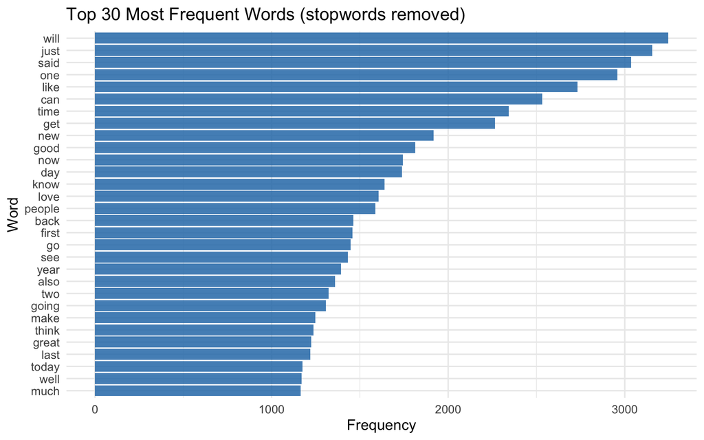

## 6. Plan for the Prediction Algorithm and Shiny App

**Algorithm:**  
The prediction model will use an **n-gram language model** (unigrams, bigrams, trigrams). The approach is:

1. Build frequency tables of n-grams from the full cleaned corpus.
2. Use a **backoff strategy** (Katz backoff or Stupid Backoff): if a trigram is not found, fall back to bigram, then unigram.
3. Return the top-3 most likely next words given the user’s input.

**Shiny App:**  
A simple interface where the user types a partial sentence and the app suggests the next word in real time. The model will be pre-computed and stored as an `.rds` file for fast lookup.

**Key considerations:**

- Profanity filtering will be applied during corpus cleaning.
- Low-frequency n-grams (count < 3) will be pruned to reduce memory footprint.
- The app must respond in under 100ms, so efficiency in the lookup table is a priority.